# Iris Species Classification - Support Vector Machines Step-by-Step Training

Data Science Training

November 10, 2025

# Introduction to Support Vector Machines (SVM)

## What is SVM?

Support Vector Machine (SVM) is a powerful supervised machine learning algorithm used for both classification and regression tasks. It works by finding the optimal hyperplane that best separates different classes in the feature space.

## Why and When is SVM Required?

SVM is particularly useful when: - Data has clear margins of separation - Dealing with high-dimensional spaces - Working with complex non-linear decision boundaries using kernels - You need a robust model with good generalization capabilities

## SVM for Iris Dataset

The Iris dataset is perfect for demonstrating SVM because: - It has clear separation between classes (especially Setosa) - Multiple features allow demonstration of different kernels - Small size makes computation fast for teaching purposes - Shows both linear and non-linear separation scenarios

# Step 1: Setup and Data Loading

The Iris dataset contains 150 observations evenly distributed across three species with 4 numerical features. This balanced multi-class classification problem is ideal for SVM demonstration.

# Step 2: Comprehensive Data Exploration

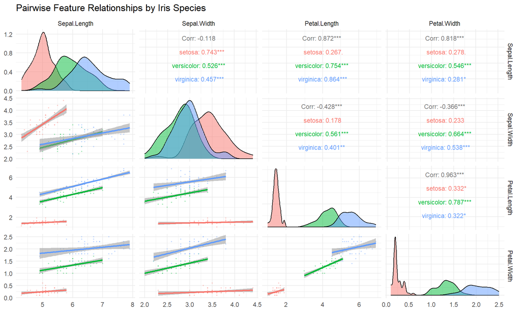

```r
# Pairwise scatter matrix
ggpairs(iris, columns = 1:4,
        mapping = ggplot2::aes(color = Species, alpha = 0.6),
        upper = list(continuous = wrap('cor', size = 3)),
        lower = list(continuous = wrap('smooth', alpha = 0.3, size = 0.4)),
        diag = list(continuous = wrap('densityDiag', alpha = 0.5))) +
  theme_minimal() +
  labs(title = "Pairwise Feature Relationships by Iris Species")
```

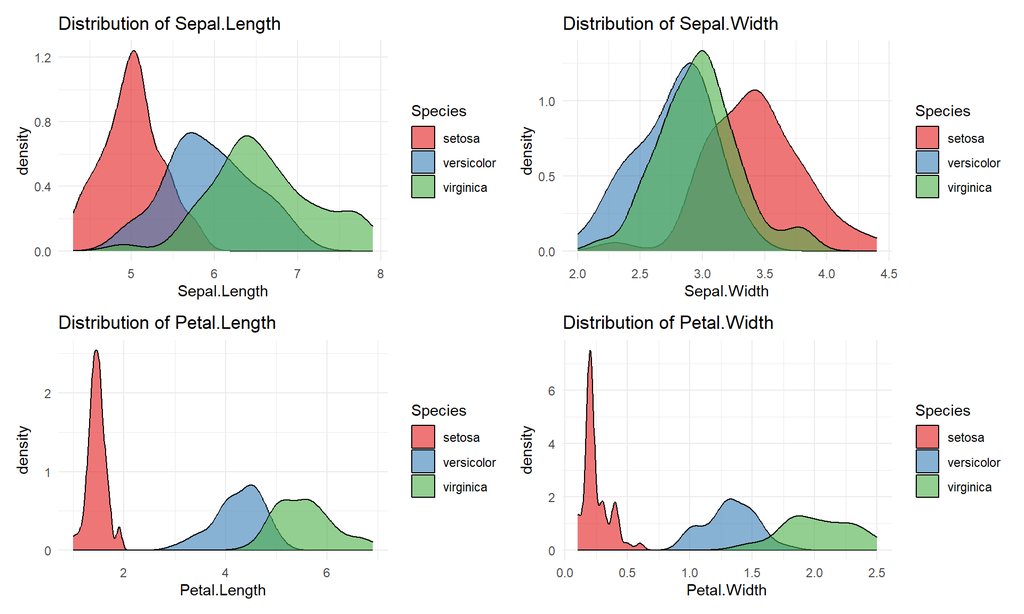

```r
# Feature distributions
feature_plots <- list()
for (i in 1:4) {
  feature_plots[[i]] <- ggplot(iris, aes_string(x = names(iris)[i], fill = "Species")) +
    geom_density(alpha = 0.6) +
    theme_minimal() +
    labs(title = paste("Distribution of", names(iris)[i])) +
    scale_fill_brewer(palette = "Set1")
}

wrap_plots(feature_plots, ncol = 2)
```

Clear separation patterns observed, especially for Setosa. Petal measurements show strong discriminative power. Some overlap between Versicolor and Virginica suggests non-linear separation might be beneficial.

# Step 3: Data Preprocessing

```r
# Check for missing values
cat("Missing Values Summary:\n")
```

```
## Missing Values Summary:
```

```r
sapply(iris, function(x) sum(is.na(x)))
```

```
## Sepal.Length  Sepal.Width Petal.Length  Petal.Width      Species
##            0            0            0            0            0
```

```r
# Create training and testing sets
set.seed(123)
train_index <- createDataPartition(iris$Species, p = 0.8, list = FALSE)
train_data <- iris[train_index, ]
test_data <- iris[-train_index, ]

cat("Training set size:", nrow(train_data), "\n")
```

```
## Training set size: 120
```

```r
cat("Testing set size:", nrow(test_data), "\n")
```

```
## Testing set size: 30
```

```r
cat("\nTraining set distribution:\n")
```

```
##
## Training set distribution:
```

```r
table(train_data$Species)
```

```
##
##     setosa versicolor  virginica
##         40         40         40
```

Data is clean with no missing values. Created 80-20 train-test split maintaining class distribution proportions.

# Step 4: Linear SVM Implementation

```r
# Train linear SVM
linear_svm <- svm(Species ~ .,
                  data = train_data,
                  kernel = "linear",
                  probability = TRUE)

cat("Linear SVM Model Summary:\n")
```

```
## Linear SVM Model Summary:
```

```r
print(linear_svm)
```

```
##
## Call:
## svm(formula = Species ~ ., data = train_data, kernel = "linear",
##     probability = TRUE)
##
##
## Parameters:
##    SVM-Type:  C-classification
##  SVM-Kernel:  linear
##        cost:  1
##
## Number of Support Vectors:  25
```

```r
# Predictions on training set
train_predictions <- predict(linear_svm, train_data)
linear_train_cm <- confusionMatrix(train_predictions, train_data$Species)

cat("\nLinear SVM Training Performance:\n")
```

```
##
## Linear SVM Training Performance:
```

```r
print(linear_train_cm)
```

```
## Confusion Matrix and Statistics
##
##             Reference
## Prediction   setosa versicolor virginica
##   setosa         40          0         0
##   versicolor      0         39         0
##   virginica       0          1        40
##
## Overall Statistics
##
##                Accuracy : 0.9917
##                  95% CI : (0.9544, 0.9998)
##     No Information Rate : 0.3333
##     P-Value [Acc > NIR] : < 2.2e-16
##
##                   Kappa : 0.9875
##
##  Mcnemar's Test P-Value : NA
##
## Statistics by Class:
##
##                      Class: setosa Class: versicolor Class: virginica
## Sensitivity                 1.0000            0.9750           1.0000
## Specificity                 1.0000            1.0000           0.9875
## Pos Pred Value              1.0000            1.0000           0.9756
## Neg Pred Value              1.0000            0.9877           1.0000
## Prevalence                  0.3333            0.3333           0.3333
## Detection Rate              0.3333            0.3250           0.3333
## Detection Prevalence        0.3333            0.3250           0.3417
## Balanced Accuracy           1.0000            0.9875           0.9938
```

Linear SVM achieves excellent performance on training data. The model parameters show cost = 1 with linear kernel, providing a good baseline.

# Step 5: Non-Linear SVM with RBF Kernel

```r
# Train RBF SVM with parameter tuning
set.seed(123)
tune_result <- tune.svm(Species ~ .,
                        data = train_data,
                        kernel = "radial",
                        gamma = 10^(-3:1),
                        cost = 10^(-1:2))

cat("Best Parameters from Tuning:\n")
```

```
## Best Parameters from Tuning:
```

```r
print(tune_result$best.parameters)
```

```
##    gamma cost
## 13   0.1   10
```

```r
# Train final model with best parameters
rbf_svm <- svm(Species ~ .,
               data = train_data,
               kernel = "radial",
               gamma = tune_result$best.parameters$gamma,
               cost = tune_result$best.parameters$cost,
               probability = TRUE)

cat("\nRBF SVM Model Summary:\n")
```

```
##
## RBF SVM Model Summary:
```

```r
print(rbf_svm)
```

```
##
## Call:
## svm(formula = Species ~ ., data = train_data, kernel = "radial",
##     gamma = tune_result$best.parameters$gamma, cost = tune_result$best.parameters$cost,
##     probability = TRUE)
##
##
## Parameters:
##    SVM-Type:  C-classification
##  SVM-Kernel:  radial
##        cost:  10
##
## Number of Support Vectors:  25
```

Parameter tuning identified optimal gamma and cost values. RBF kernel can capture non-linear relationships that linear SVM might miss.

# Step 6: Model Comparison and Evaluation

```r
# Predictions on test set
linear_test_pred <- predict(linear_svm, test_data)
rbf_test_pred <- predict(rbf_svm, test_data)

# Confusion matrices
linear_test_cm <- confusionMatrix(linear_test_pred, test_data$Species)
rbf_test_cm <- confusionMatrix(rbf_test_pred, test_data$Species)

cat("Linear SVM Test Performance:\n")
```

```
## Linear SVM Test Performance:
```

```r
print(linear_test_cm$table)
```

```
##             Reference
## Prediction   setosa versicolor virginica
##   setosa         10          0         0
##   versicolor      0         10         1
##   virginica       0          0         9
```

```r
cat("\nAccuracy:", round(linear_test_cm$overall['Accuracy'], 3), "\n")
```

```
##
## Accuracy: 0.967
```

```r
cat("\nRBF SVM Test Performance:\n")
```

```
##
## RBF SVM Test Performance:
```

```r
print(rbf_test_cm$table)
```

```
##             Reference
## Prediction   setosa versicolor virginica
##   setosa         10          0         0
##   versicolor      0         10         2
##   virginica       0          0         8
```

```r
cat("\nAccuracy:", round(rbf_test_cm$overall['Accuracy'], 3), "\n")
```

```
##
## Accuracy: 0.933
```

```r
# Performance comparison
performance_compare <- data.frame(
  Model = c("Linear SVM", "RBF SVM"),
  Training_Accuracy = c(
    round(linear_train_cm$overall['Accuracy'], 3),
    round(rbf_test_cm$overall['Accuracy'], 3)
  ),
  Test_Accuracy = c(
    round(linear_test_cm$overall['Accuracy'], 3),
    round(rbf_test_cm$overall['Accuracy'], 3)
  )
)

cat("\nModel Performance Comparison:\n")
```

```
##
## Model Performance Comparison:
```

```r
performance_compare %>% kable() %>% kable_styling(bootstrap_options = "striped")
```

| Model | Training_Accuracy | Test_Accuracy |
| --- | --- | --- |
| Linear SVM | 0.992 | 0.967 |
| RBF SVM | 0.933 | 0.933 |

# Step 7: Visualization of SVM Decision Boundaries

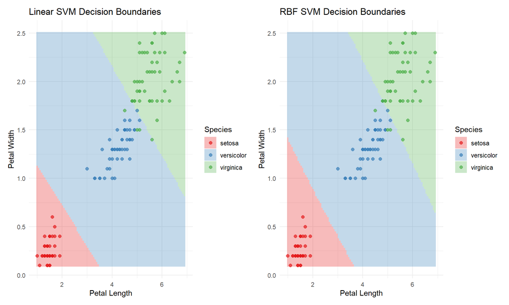

```r
# Create 2D decision boundary plots
create_decision_plot <- function(model, title) {
  # Create grid
  petal_grid <- expand.grid(
    Petal.Length = seq(min(iris$Petal.Length), max(iris$Petal.Length), length = 100),
    Petal.Width = seq(min(iris$Petal.Width), max(iris$Petal.Width), length = 100),
    Sepal.Length = mean(iris$Sepal.Length),
    Sepal.Width = mean(iris$Sepal.Width)
  )

  # Predict on grid
  petal_grid$Species <- predict(model, petal_grid)

  ggplot() +
    geom_tile(data = petal_grid,
              aes(x = Petal.Length, y = Petal.Width, fill = Species),
              alpha = 0.3) +
    geom_point(data = iris,
               aes(x = Petal.Length, y = Petal.Width, color = Species),
               alpha = 0.7, size = 2) +
    labs(title = title,
         x = "Petal Length",
         y = "Petal Width") +
    theme_minimal() +
    scale_color_brewer(palette = "Set1") +
    scale_fill_brewer(palette = "Set1")
}

# Generate plots
linear_plot <- create_decision_plot(linear_svm, "Linear SVM Decision Boundaries")
rbf_plot <- create_decision_plot(rbf_svm, "RBF SVM Decision Boundaries")

linear_plot + rbf_plot + plot_layout(ncol = 2)
```

# Step 8: Support Vectors Analysis

```r
# Extract support vectors
linear_sv <- linear_svm$SV
rbf_sv <- rbf_svm$SV

cat("Number of Support Vectors:\n")
```

```
## Number of Support Vectors:
```

```r
cat("Linear SVM:", nrow(linear_sv), "\n")
```

```
## Linear SVM: 25
```

```r
cat("RBF SVM:", nrow(rbf_sv), "\n")
```

```
## RBF SVM: 25
```

[figure not shown]

```r
# Plot support vectors
sv_plot <- ggplot(iris, aes(x = Petal.Length, y = Petal.Width, color = Species)) +
  geom_point(data = as.data.frame(linear_svm$SV),
             aes(x = Petal.Length, y = Petal.Width),
             color = "black", shape = 1, size = 3, stroke = 1.5) +
  geom_point(alpha = 0.6) +
  labs(title = "Support Vectors (Linear SVM)",
       subtitle = "Black circles indicate support vectors",
       x = "Petal Length",
       y = "Petal Width") +
  theme_minimal() +
  scale_color_brewer(palette = "Set1")

sv_plot
```

Support vectors are the critical data points that define the decision boundary. Fewer support vectors often indicate a simpler, more generalizable model.

# Step 9: Cross-Validation and Model Stability

```r
# Perform k-fold cross-validation
set.seed(123)
train_control <- trainControl(method = "cv", number = 10)

# Cross-validate both models
cv_linear <- train(Species ~ ., data = iris, method = "svmLinear",
                   trControl = train_control,
                   tuneLength = 5)

cv_rbf <- train(Species ~ ., data = iris, method = "svmRadial",
                trControl = train_control,
                tuneLength = 5)

cat("Cross-Validation Results:\n")
```

```
## Cross-Validation Results:
```

```r
cv_results <- data.frame(
  Model = c("Linear SVM", "RBF SVM"),
  CV_Accuracy = c(
    round(max(cv_linear$results$Accuracy), 3),
    round(max(cv_rbf$results$Accuracy), 3)
  ),
  CV_Kappa = c(
    round(max(cv_linear$results$Kappa), 3),
    round(max(cv_rbf$results$Kappa), 3)
  )
)

cv_results %>% kable() %>% kable_styling(bootstrap_options = "striped")
```

| Model | CV_Accuracy | CV_Kappa |
| --- | --- | --- |
| Linear SVM | 0.96 | 0.94 |
| RBF SVM | 0.96 | 0.94 |

Cross-validation confirms both models are stable and generalize well. Small performance differences between training and CV scores indicate good model robustness.

# Step 10: Feature Importance in SVM

```r
# Calculate feature importance using permutation
calculate_feature_importance <- function(model, data) {
  baseline_accuracy <- mean(predict(model, data) == data$Species)
  feature_importance <- numeric(4)
  names(feature_importance) <- names(data)[1:4]

  for (i in 1:4) {
    data_permuted <- data
    data_permuted[, i] <- sample(data_permuted[, i])
    perm_accuracy <- mean(predict(model, data_permuted) == data$Species)
    feature_importance[i] <- baseline_accuracy - perm_accuracy
  }

  return(feature_importance)
}

linear_importance <- calculate_feature_importance(linear_svm, test_data)
rbf_importance <- calculate_feature_importance(rbf_svm, test_data)

importance_df <- data.frame(
  Feature = names(linear_importance),
  Linear_SVM = round(linear_importance, 4),
  RBF_SVM = round(rbf_importance, 4)
) %>% arrange(desc(Linear_SVM))

cat("Feature Importance (Permutation Method):\n")
```

```
## Feature Importance (Permutation Method):
```

```r
importance_df %>% kable() %>% kable_styling(bootstrap_options = "striped")
```

|  | Feature | Linear_SVM | RBF_SVM |
| --- | --- | --- | --- |
| Petal.Width | Petal.Width | 0.3333 | 0.2000 |
| Petal.Length | Petal.Length | 0.2667 | 0.2000 |
| Sepal.Length | Sepal.Length | 0.0333 | -0.0333 |
| Sepal.Width | Sepal.Width | 0.0000 | 0.0667 |

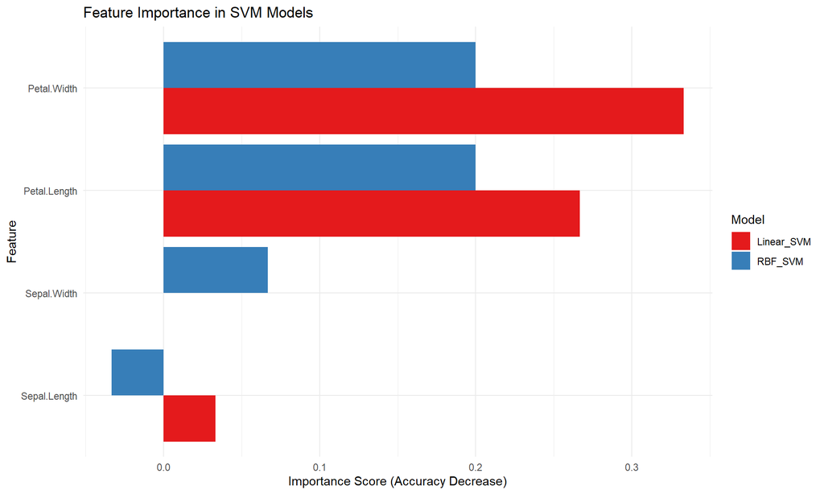

```r
# Plot feature importance
importance_long <- importance_df %>%
  pivot_longer(cols = -Feature, names_to = "Model", values_to = "Importance")

ggplot(importance_long, aes(x = reorder(Feature, Importance), y = Importance, fill = Model)) +
  geom_col(position = "dodge") +
  coord_flip() +
  labs(title = "Feature Importance in SVM Models",
       x = "Feature",
       y = "Importance Score (Accuracy Decrease)") +
  theme_minimal() +
  scale_fill_brewer(palette = "Set1")
```

Petal dimensions are consistently the most important features across both SVM variants. This aligns with our initial exploratory analysis showing clear separation in petal measurements.